# Homework 4

```python
# -*- coding: utf-8 -*-
import numpy as np
import pandas as pa
import matplotlib.pyplot as plt
import seaborn as sn
import numpy.random as rn
minor = pa.read_csv('C:/Users/arcti/Documents/Fund_of_Data/human-development/human_development.csv')
```

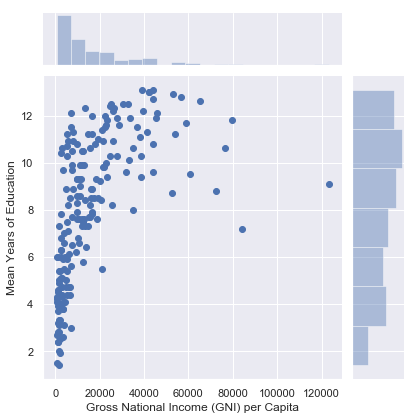

```python
sn.set(style = 'darkgrid')
sn.jointplot(x="Gross National Income (GNI) per Capita", y="Mean Years of Education", data=minor);
```

```
[Text(0,0.5,'All Countries')]
```

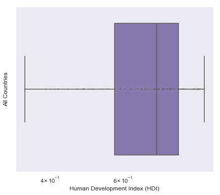

```python
# temp = list(minor.columns.values)
f, ax = plt.subplots(figsize=(7, 6))
ax.set_xscale("log")
sn.boxplot(x="Human Development Index (HDI)", palette=["m", "g"], data=minor)
sn.swarmplot(x="Human Development Index (HDI)", data=minor,
              size=1, color=".3", linewidth=0)
ax.xaxis.grid(True)
ax.set(ylabel="All Countries")
```

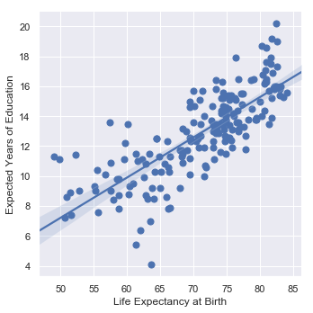

```python
sn.lmplot(x="Life Expectancy at Birth", y="Expected Years of Education", data=minor,
          scatter_kws={"s": 50, "alpha": 1})
```

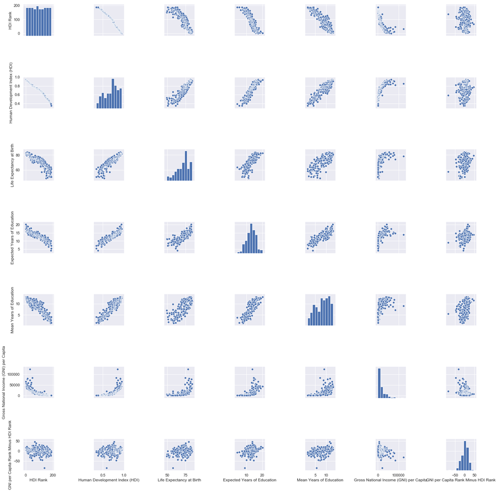

```python
sn.set(style = 'darkgrid')

p = sn.pairplot(minor)

p.fig.set_size_inches(20, 20)
```

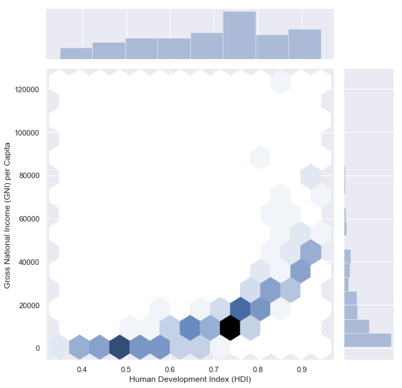

```python
sn.set(style = 'darkgrid')

sn.jointplot(x='Human Development Index (HDI)', y='Gross National Income (GNI) per Capita', data=minor, height=8, kind='hex');
```

This data is mostly numerical with category of countries, 8 variables, and some missing pieces. It is the human development section of a collection of data found at https://www.kaggle.com/undp/human-development It is from the United Nations Development Program and centers around the Human Development Index (HDI); the geometric mean of normalized indices for the data variables of life expectancy, educatiion, and Gross National Income

Potential problems/questions include:

- Does missing some data for certain countries allow them to have a potentially higher HDI ranking than they may deserve? (Does the HDI have flaws in it's validity?)
- Does increasing education help the Gross National income increase?
- Are all variables carrying the same weight in the HDI? (How is the HDI calculated exactly?)